# Lab 6 - BINF 6310

Erin Tsai

### Problem 1:

##### This question uses data from this paper: https://science.sciencemag.org/content/347/6217/78

#### Variation in cancer risk among tissues can be explained by the number of stem cell divisions. Science 02 Jan 2015: Vol. 347, Issue 6217, pp. 78-81

###### 1A) Download the data from here examining the relationship between the number of cell divisions and cancer risk: https://fodorclasses.github.io/classes/stats2020/cancerRisk.txt

###### On a log10-log10 scale graph Lifetime_cancer_risk (on the y-axis) vs. CumulativeCellDivisions (on the x-axis). (This reproduces Fig. 1 from the paper). (You can read in the file with read.table(“cancerRisk.txt”, header=TRUE, sep=")

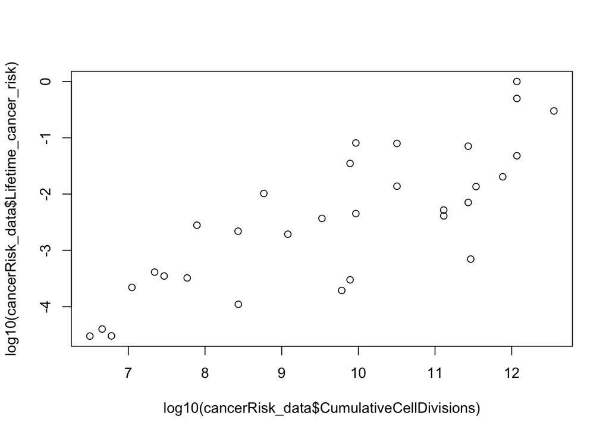

```r
cancerRisk_data = read.table("cancerRisk.txt", sep = "\t", header = TRUE)
plot(log10(cancerRisk_data$CumulativeCellDivisions), log10(cancerRisk_data$Lifetime_cancer_risk))
```

###### 1B) Using the lm function, fit a linear model with Lifetime_cancer_risk as the Y variable and CumulativeCellDivisions as the x-data. Add the regression line to the plot using the function abline(myLm) (where myLm is the linear model you created).

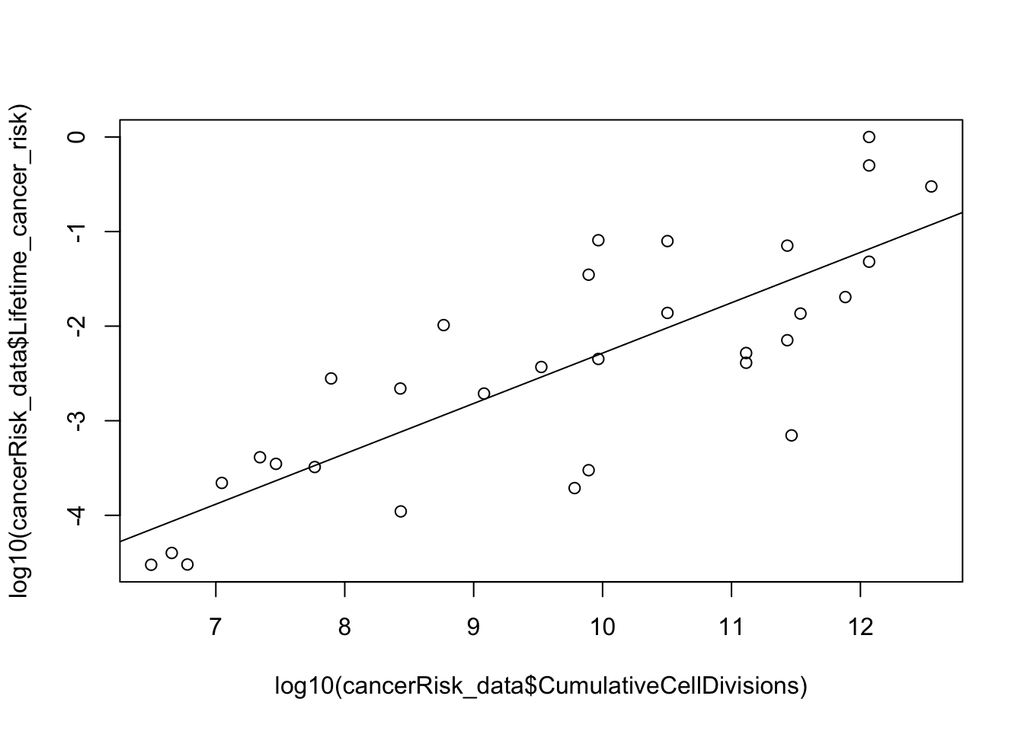

```r
plot(log10(cancerRisk_data$CumulativeCellDivisions), log10(cancerRisk_data$Lifetime_cancer_risk))
myLm = lm(log10(cancerRisk_data$Lifetime_cancer_risk) ~ log10(cancerRisk_data$CumulativeCellDivisions))
abline(myLm)
```

```r
x = summary(myLm)
pval = anova(myLm)$"Pr(>F)"[1]
rsquare = x$r.squared
```

###### 1D) Are the assumptions of constant variance and normal distribution of the residues reasonable for this model? Justify your answer.

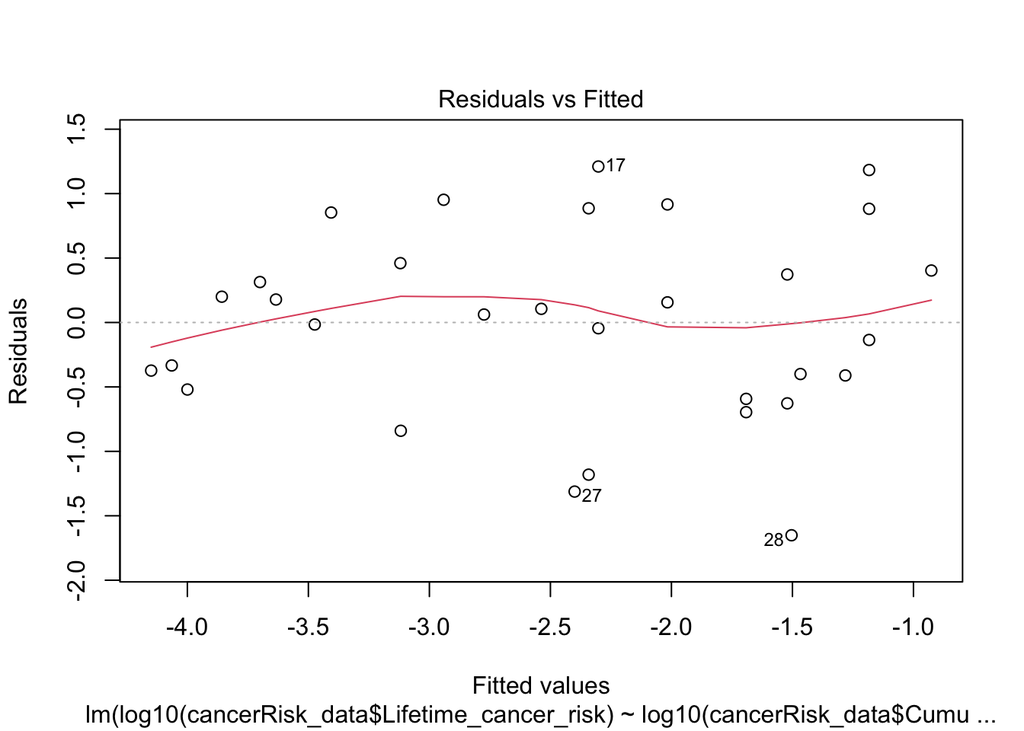

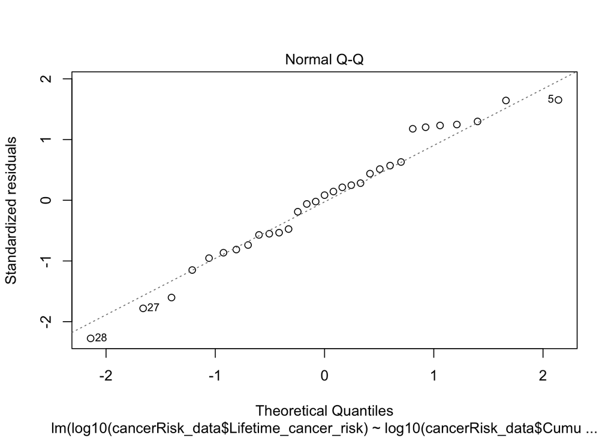

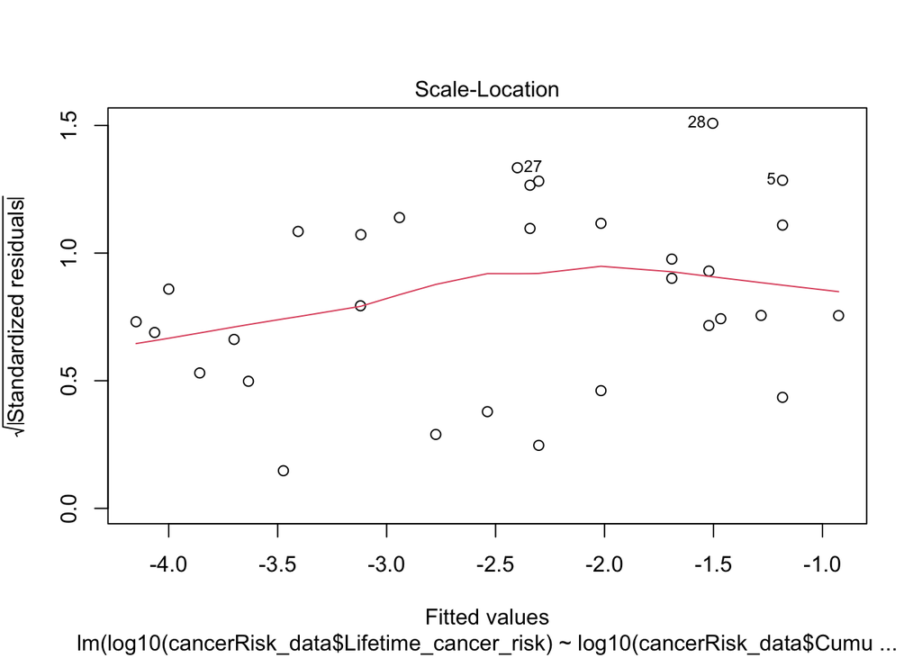

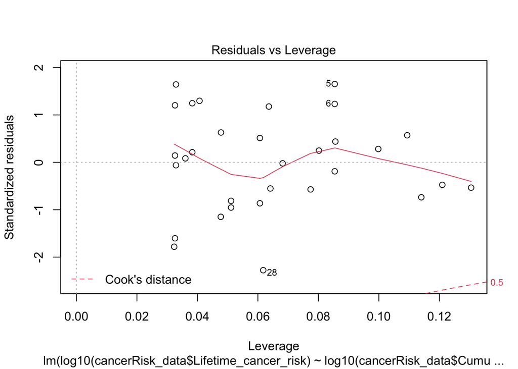

```r
plot(myLm)
```

- Based off of the Residuals vs. Fitted plot, it looks like it there is constant variance.
- Based off of the QQ-norm plot, we can assume that the residuals have a normal distribution because the values form a line that is roughly straight.

### Problem 2:

##### Consider the case-control file for the colorectal adenomas data set that is here: http://afodor.github.io/classes/stats2015/caseControlData.txt

##### A separate file gives obesity (BMI) data for these same subjects: http://afodor.github.io/classes/stats2015/BMI_Data.txt

##### For each OTU in the spreadsheet, generate a p-value from linear regression comparing BMI to the relative abundance of each OTU. Graph out all the p-values. Hints: To lookup the ids in the BMI table, you will need to some processing on the “sample” column in the caseControl file.

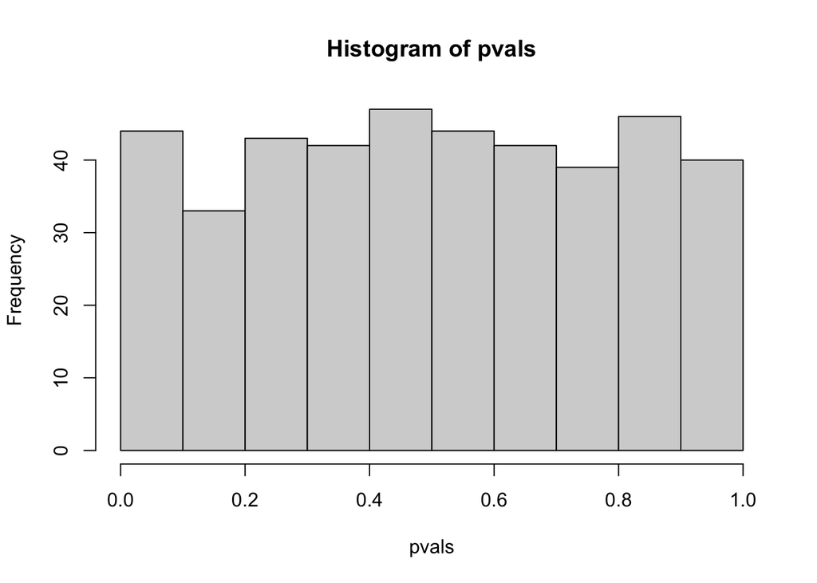

```r
caseControl_data = read.table("caseControlData.txt", header = TRUE)
sampleID = caseControl_data$sample

key = sub("case", "", sampleID)
key = sub("control", "", key)

key = strsplit(key, "_")
lst = c()
for(i in 1:length(key)){
  lst[i] = key[[i]][1]
}
caseControl_data$sample = lst

bmi_data = read.table("BMI_Data.txt", header = TRUE, sep = "\t")

merge_data = merge(bmi_data, caseControl_data, by.x = "studyid", by.y = "sample")

pvals = c()
a = 1
for(i in 3:ncol(merge_data)){
  myLm1 = lm(merge_data$bmi ~ merge_data[,i])
  pvals[a] = anova(myLm1)$'Pr(>F)'[1]
  a = a + 1
}

hist(pvals)
```

###### Do they appear uniformly distributed?

- The p-values seem to be relatively uniformly distributed, based on the above histogram.

###### Does the microbial community appear to be influencing body weight in this cohort?

- According to the histogram, it does not seem like the microbial community has any influence on BMI in this cohort (as it seems that the p-values seem to have relative equal probability).

###### Are any of these associations significant at a 10% false discovery rate?

```r
fdr_results = sum(p.adjust(pvals, 'BH') < 0.10)
```

- **0** of these associations are significant at a 10% false discovery rate.